# Module Socle - Exercice

- Manipulation des objets R sans recours à une base de données
- Importation d’une base de données à partir d’un fichier CSV et premières manipulations
- Premiers graphiques et statistiques.

Par défaut, les résultats attendus sont affichés, et, si vous séchez, vous pouvez afficher le code les ayant généré en cliquant sur “code”. A tout moment, vous pouvez donc copier / coller le code dans l’éditeur de script ou la console pour exécuter les commandes présentées. Ces exercices nécessitent les packages de base et le package `tidyverse`, qui regroupe un ensemble de packages à la syntaxe très simple.

```r
require(tidyverse)       # ou library(tidyverse)
```

# Création et manipulation d’objets dans R

## Génération de vecteurs

Créez trois vecteur : un numérique, un caractère et un facteur. Vous pouvez vous aider des fonctions `c()`, `rnorm()` (génération d’une variable aléatoire selon une loi normale), `seq()` ou `rep()`

```r
rm(list=ls())
x <- c(1,160,2,9,60)
x1 <- c("Je","programme","en","R") # Guillemets pour indiquer que c'est une variable textuelle
y <- seq(1,10)
z <- rep(1,100)
x <- rnorm(n = 30)
# création de vecteurs avec la fonction c() = combine
v1 <- c(3,4,12,15,32,6,1,2,3,9)
# avec la fonction seq() = sequence, g?n?ralisation de la syntaxe ci-dessus
v2 <- seq(1 , 15 , 1.5)
# syntaxe équivalente mais préférable car plus lisible :
v2b<-seq(from=1 , to=15 , by=1.5)
v3<-1:10
# avec la fonction rep() = répétition
v4<-rep(4,10)
# ces commandes peuvent être combinées. Pratique pour cr?er des variables "facteur"
v5 <- rep(c(3,4,1.2,8,9),2)
v6 <- rep(1:5,2)
# vecteurs de type texte ou factor
vtaille <- rep(c("S","L"),5)
vtaille <- factor(vtaille)
# concaténation de vecteurs
gtaille <- paste("X",vtaille,sep="")
gtaille <- factor(gtaille)
toutes_taille <- c(as.character(vtaille),as.character(gtaille))
toutes_taille <- as.factor(toutes_taille)
levels(toutes_taille)
```

```
[1] "L"  "S"  "XL" "XS"
```

Regroupez ces variables dans un dataframe, puis dans une liste. Dans les deux configurations, affichez la variable contenant les tailles (vtaille). Pour la liste, vous pouvez utiliser les [] et [[]].

## Génération d’autres objets

### Dataframes et listes

```r
dataf <- data.frame(vtaille,v1,v2,v3,v4,v5,v6)
liste <- list(vtaille,v1,v2,v3,v4,v5,v6)
names(liste) <- c("vtaille","v1","v2","v3","v4","v5","v6")
dataf$vtaille
```

```
 [1] S L S L S L S L S L
Levels: L S
```

```r
liste$vtaille
```

```
 [1] S L S L S L S L S L
Levels: L S
```

```r
rm(dataf,vtaille,v1,v2,v2b,v3,v4,v5,v6)
```

### Pour aller plus loin : matrices et arrays

- Créer une matrice à 10 lignes et 10 colonnes remplie avec un tirage aléatoire selon une loi normale centrée réduit.
- Créer un hypercube avec la fonction `array()` avec 10 lignes, colonnes et de profondeur 3, toujours avec un tirage aléatoire selon une loi normale

```r
mat <- matrix(rnorm(100),ncol = 10, nrow = 10)
arr <- array(rnorm(300),dim = c(10,10,3))
mat
```

```
             [,1]        [,2]       [,3]        [,4]        [,5]       [,6]        [,7]        [,8]
 [1,] -0.55869294  0.31517616 -0.1508674  1.30954472 -0.15220698 -0.3107769  0.60439588 -0.07795541
 [2,]  0.65994429 -1.00861246  0.3877243 -0.83069957 -0.87387632 -0.6979785 -0.84378611  1.39004606
 [3,]  1.04153236 -0.53579244 -1.2172456 -0.58408127 -0.41464899 -0.2796532  0.58484257  0.48442100
 [4,] -0.38353136  0.91970676 -0.1186334 -1.17104560  1.18896394 -0.4067962  0.16955974 -1.00908798
 [5,] -0.19374938 -0.30559980 -0.5939333 -0.26895950  0.35568269 -0.9845250  0.10039125  1.57051298
 [6,] -1.79031227 -1.40175795  1.8986935  2.46577507 -0.88354745 -0.8715976  0.07288099  0.36928890
 [7,]  0.49039014 -0.38581564  1.1280064  0.06492189 -1.22765646  1.0241834  1.27524724 -2.02885817
 [8,]  0.05357252 -1.18112289 -0.4246718  1.08434827  0.29078864  1.3994847 -2.78548909 -0.04429784
 [9,] -0.64635630  0.83656355 -0.4259737  0.65951752  0.20574625  1.8928153  0.49168295  0.38957565
[10,]  2.10134953 -0.01839049 -1.1140906  1.15543633  0.09918835  0.5463260 -0.99339141 -0.85796579
             [,9]      [,10]
 [1,]  0.66317925 -0.8605454
 [2,]  0.16266076  1.0128653
 [3,]  1.30640075  0.9734050
 [4,]  0.41970053 -0.7266226
 [5,]  0.24466230 -0.1817904
 [6,]  0.25997323 -0.8076716
 [7,]  0.07985226  0.6105990
 [8,]  0.90486661  0.7254893
 [9,]  0.48354025  0.3143448
[10,] -2.41079032  0.6853988
```

```r
arr
```

```
, , 1

             [,1]        [,2]        [,3]        [,4]        [,5]        [,6]       [,7]       [,8]
 [1,] -0.36143877  0.04447597 -0.56891135 -1.84801635  0.88993062 -0.83712863  2.0125505  1.5929187
 [2,] -0.01063036 -1.45167608  1.30332226  0.09341696 -0.08670982 -1.78982167  0.2602235  0.8794239
 [3,]  0.52335206 -0.12961975 -0.26928700 -1.62372212  0.76533356 -0.39339401  0.2454552 -1.6022998
 [4,] -0.59921507 -0.23738569 -1.80258625  0.48503944 -0.11886567 -0.77939707 -1.3133019  0.5599780
 [5,] -1.43160252  1.50882067  0.16073745 -0.17236670  0.59316272  1.98849154 -1.1623384 -0.8785842
 [6,]  0.29201167  1.08881735 -0.83382078 -0.16448155  0.31588893  0.42475880 -1.5189792  1.7473815
 [7,] -1.07681382 -1.08918568 -0.69565776 -1.41759978  0.78513076  0.03291547  0.1091551  0.7538998
 [8,]  1.55964779 -2.38353533  0.06126744  0.14037680  0.03144666 -1.38388151  0.2138311 -0.5724238
 [9,] -1.22991136  0.94811829 -0.20463705  0.03120990  0.90741101  0.76715468  1.5366767 -0.1123158
[10,]  1.17468162 -1.37195286  0.16798648  1.20626105  0.86795764 -0.06286322  0.5083747 -1.4581444
            [,9]       [,10]
 [1,]  0.1425704 -0.68644879
```

[output cut: 59 more lines]

*Pourquoi s’embêter avec ça ?* Parce qu’on peut appliquer des fonctions facilement sur les lignes, colonnes et autres dimensions. Exemple : résultats de validations croisées par bloc, simulations de loi selon différents paramètres. Et on calcule facilement des statistiques “marginales”.

```r
apply(arr,MARGIN = 3,FUN=mean)
```

```
[1] -0.04129595  0.19492664  0.11182392
```

```r
apply(arr,MARGIN = c(2,3),FUN = mean)
```

```
             [,1]        [,2]        [,3]
 [1,] -0.11599187  0.58635105  0.17163622
 [2,] -0.30731231 -0.30433712  0.50387275
 [3,] -0.26815866  0.05982784  0.47544548
 [4,] -0.32698823 -0.07424151  0.12593824
 [5,]  0.49506864  0.16862176  0.09172900
 [6,] -0.20331656  0.60276970 -0.22144501
 [7,]  0.08916473  0.52976629 -0.25920313
 [8,]  0.09098338  0.05582319  0.49452000
 [9,] -0.43476330  0.73246365 -0.34181103
[10,]  0.56835466 -0.40777843  0.07755669
```

**Le coin du capitaine [ ]**

[figure not shown]

Le crochet, c’est comme le capitaine du même nom : personne ne l’aime, mais sans lui, pas de Peter Pan, pas de Neverland ! Moralité, on s’en sert beacoup pour pimenter les codes ! On peut utiliser les crochets pour accéder aux éléments des matrices/arrays et dataframe/listes.

- Matrices et arrays

```r
mat[1,1]
```

```
[1] -0.5586929
```

```r
mat[1,]
```

```
 [1] -0.55869294  0.31517616 -0.15086742  1.30954472 -0.15220698 -0.31077692  0.60439588 -0.07795541
 [9]  0.66317925 -0.86054537
```

```r
mat[,1]
```

```
 [1] -0.55869294  0.65994429  1.04153236 -0.38353136 -0.19374938 -1.79031227  0.49039014  0.05357252
 [9] -0.64635630  2.10134953
```

```r
arr[1,1,1]
```

```
[1] -0.3614388
```

```r
arr[1,,]
```

```
             [,1]        [,2]       [,3]
 [1,] -0.36143877  0.59140209  1.8428228
 [2,]  0.04447597 -1.03925368  2.1605312
 [3,] -0.56891135 -0.69003320  0.6461455
 [4,] -1.84801635 -1.00793593  0.3550093
 [5,]  0.88993062  0.13482797 -0.0523553
 [6,] -0.83712863 -0.71466724 -0.3358870
 [7,]  2.01255050  0.07296931 -2.1134336
 [8,]  1.59291872  0.17990271  0.1262935
 [9,]  0.14257045 -0.20626842 -0.1749651
[10,] -0.68644879 -0.15739775 -0.1269791
```

```r
arr[,,1]
```

```
             [,1]        [,2]        [,3]        [,4]        [,5]        [,6]       [,7]       [,8]
 [1,] -0.36143877  0.04447597 -0.56891135 -1.84801635  0.88993062 -0.83712863  2.0125505  1.5929187
 [2,] -0.01063036 -1.45167608  1.30332226  0.09341696 -0.08670982 -1.78982167  0.2602235  0.8794239
 [3,]  0.52335206 -0.12961975 -0.26928700 -1.62372212  0.76533356 -0.39339401  0.2454552 -1.6022998
 [4,] -0.59921507 -0.23738569 -1.80258625  0.48503944 -0.11886567 -0.77939707 -1.3133019  0.5599780
 [5,] -1.43160252  1.50882067  0.16073745 -0.17236670  0.59316272  1.98849154 -1.1623384 -0.8785842
 [6,]  0.29201167  1.08881735 -0.83382078 -0.16448155  0.31588893  0.42475880 -1.5189792  1.7473815
 [7,] -1.07681382 -1.08918568 -0.69565776 -1.41759978  0.78513076  0.03291547  0.1091551  0.7538998
 [8,]  1.55964779 -2.38353533  0.06126744  0.14037680  0.03144666 -1.38388151  0.2138311 -0.5724238
 [9,] -1.22991136  0.94811829 -0.20463705  0.03120990  0.90741101  0.76715468  1.5366767 -0.1123158
[10,]  1.17468162 -1.37195286  0.16798648  1.20626105  0.86795764 -0.06286322  0.5083747 -1.4581444
            [,9]       [,10]
 [1,]  0.1425704 -0.68644879
 [2,]  0.3614768  0.30898084
 [3,] -0.1877710  2.26658572
 [4,]  0.6231599 -0.31786280
 [5,] -0.9816632  0.95223891
 [6,] -2.1517769  1.02741584
 [7,] -2.3921797 -0.67934157
 [8,]  0.2068685  0.25869204
 [9,] -0.3760508  2.46170467
[10,]  0.4077330  0.09158173
```

- dataframes et listes :

Pour les dataframes, le fonctionnement est le même que pour les matrices. Pour les listes, une paire de crochet renvoie un résultat sous forme de liste, un double crochet renvoie le résultat sous sa forme naturelle (ex : vecteur ou matrice).

```r
str(liste[1])
```

```
List of 1
 $ vtaille: Factor w/ 2 levels "L","S": 2 1 2 1 2 1 2 1 2 1
```

```r
str(liste[[1]])
```

```
 Factor w/ 2 levels "L","S": 2 1 2 1 2 1 2 1 2 1
```

## Inspection d’un objet : la régression

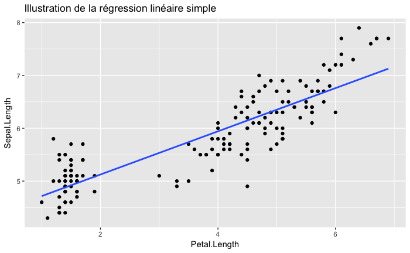

La régression linéaire consiste à exprimer une variable Y en fonction d’une variable X dans une fonction linéaire. C’est à dire qu’on cherche a et b tels que :
$$Y = a \cdot X + b + \epsilon$$
où $\epsilon$ est le résidu de la régression. On utilise dans cet exemple la table des iris de Fisher, existant dans R base qu’il suffit d’appeler avec `data(iris)` (il existe d’autres dataframe inclus dans les packages et qui sont utilisés en exemple dans l’aide).

```r
data("iris")
str(iris)
```

```
'data.frame':   150 obs. of  5 variables:
 $ Sepal.Length: num  5.1 4.9 4.7 4.6 5 5.4 4.6 5 4.4 4.9 ...
 $ Sepal.Width : num  3.5 3 3.2 3.1 3.6 3.9 3.4 3.4 2.9 3.1 ...
 $ Petal.Length: num  1.4 1.4 1.3 1.5 1.4 1.7 1.4 1.5 1.4 1.5 ...
 $ Petal.Width : num  0.2 0.2 0.2 0.2 0.2 0.4 0.3 0.2 0.2 0.1 ...
 $ Species     : Factor w/ 3 levels "setosa","versicolor",..: 1 1 1 1 1 1 1 1 1 1 ...
```

Faire la régression de la Sepal.Length sur Petal.length à l’aide de la fonction `lm()`

```r
lm(data=iris,formula = Sepal.Length~Petal.Length)
```

```
Call:
lm(formula = Sepal.Length ~ Petal.Length, data = iris)

Coefficients:
 (Intercept)  Petal.Length
      4.3066        0.4089
```

On a les paramètres a et b mais on aimerait en savoir plus… Au moins la qualité d’ajustement (le $R^2$ par exemple), et un graphique des résidus pour détecter une éventuelle structure. Pour cela, stocker le résultat dans un nouvel objet, et explorez-le avec les fonctions `str()`, `summary()` et `plot()`

```r
reg <- lm(data=iris,formula = Sepal.Length~Petal.Length)
str(reg)
```

```
List of 12
 $ coefficients : Named num [1:2] 4.307 0.409
  ..- attr(*, "names")= chr [1:2] "(Intercept)" "Petal.Length"
 $ residuals    : Named num [1:150] 0.2209 0.0209 -0.1382 -0.32 0.1209 ...
  ..- attr(*, "names")= chr [1:150] "1" "2" "3" "4" ...
 $ effects      : Named num [1:150] -71.566 8.812 -0.155 -0.337 0.104 ...
  ..- attr(*, "names")= chr [1:150] "(Intercept)" "Petal.Length" "" "" ...
 $ rank         : int 2
 $ fitted.values: Named num [1:150] 4.88 4.88 4.84 4.92 4.88 ...
  ..- attr(*, "names")= chr [1:150] "1" "2" "3" "4" ...
 $ assign       : int [1:2] 0 1
 $ qr           :List of 5
  ..$ qr   : num [1:150, 1:2] -12.2474 0.0816 0.0816 0.0816 0.0816 ...
  .. ..- attr(*, "dimnames")=List of 2
  .. .. ..$ : chr [1:150] "1" "2" "3" "4" ...
  .. .. ..$ : chr [1:2] "(Intercept)" "Petal.Length"
  .. ..- attr(*, "assign")= int [1:2] 0 1
  ..$ qraux: num [1:2] 1.08 1.1
  ..$ pivot: int [1:2] 1 2
  ..$ tol  : num 1e-07
  ..$ rank : int 2
  ..- attr(*, "class")= chr "qr"
 $ df.residual  : int 148
 $ xlevels      : Named list()
 $ call         : language lm(formula = Sepal.Length ~ Petal.Length, data = iris)
 $ terms        :Classes 'terms', 'formula'  language Sepal.Length ~ Petal.Length
  .. ..- attr(*, "variables")= language list(Sepal.Length, Petal.Length)
  .. ..- attr(*, "factors")= int [1:2, 1] 0 1
  .. .. ..- attr(*, "dimnames")=List of 2
  .. .. .. ..$ : chr [1:2] "Sepal.Length" "Petal.Length"
  .. .. .. ..$ : chr "Petal.Length"
  .. ..- attr(*, "term.labels")= chr "Petal.Length"
  .. ..- attr(*, "order")= int 1
  .. ..- attr(*, "intercept")= int 1
  .. ..- attr(*, "response")= int 1
  .. ..- attr(*, ".Environment")=<environment: R_GlobalEnv>
  .. ..- attr(*, "predvars")= language list(Sepal.Length, Petal.Length)
  .. ..- attr(*, "dataClasses")= Named chr [1:2] "numeric" "numeric"
  .. .. ..- attr(*, "names")= chr [1:2] "Sepal.Length" "Petal.Length"
 $ model        :'data.frame':  150 obs. of  2 variables:
  ..$ Sepal.Length: num [1:150] 5.1 4.9 4.7 4.6 5 5.4 4.6 5 4.4 4.9 ...
  ..$ Petal.Length: num [1:150] 1.4 1.4 1.3 1.5 1.4 1.7 1.4 1.5 1.4 1.5 ...
  ..- attr(*, "terms")=Classes 'terms', 'formula'  language Sepal.Length ~ Petal.Length
  .. .. ..- attr(*, "variables")= language list(Sepal.Length, Petal.Length)
  .. .. ..- attr(*, "factors")= int [1:2, 1] 0 1
  .. .. .. ..- attr(*, "dimnames")=List of 2
  .. .. .. .. ..$ : chr [1:2] "Sepal.Length" "Petal.Length"
  .. .. .. .. ..$ : chr "Petal.Length"
  .. .. ..- attr(*, "term.labels")= chr "Petal.Length"
  .. .. ..- attr(*, "order")= int 1
  .. .. ..- attr(*, "intercept")= int 1
  .. .. ..- attr(*, "response")= int 1
  .. .. ..- attr(*, ".Environment")=<environment: R_GlobalEnv>
  .. .. ..- attr(*, "predvars")= language list(Sepal.Length, Petal.Length)
  .. .. ..- attr(*, "dataClasses")= Named chr [1:2] "numeric" "numeric"
  .. .. .. ..- attr(*, "names")= chr [1:2] "Sepal.Length" "Petal.Length"
 - attr(*, "class")= chr "lm"
```

```r
summary(reg)
```

```
Call:
lm(formula = Sepal.Length ~ Petal.Length, data = iris)

Residuals:
     Min       1Q   Median       3Q      Max
-1.24675 -0.29657 -0.01515  0.27676  1.00269

Coefficients:
             Estimate Std. Error t value Pr(>|t|)
(Intercept)   4.30660    0.07839   54.94   <2e-16 ***
Petal.Length  0.40892    0.01889   21.65   <2e-16 ***
---
Signif. codes:  0 ‘***’ 0.001 ‘**’ 0.01 ‘*’ 0.05 ‘.’ 0.1 ‘ ’ 1

Residual standard error: 0.4071 on 148 degrees of freedom
Multiple R-squared:   0.76, Adjusted R-squared:  0.7583
F-statistic: 468.6 on 1 and 148 DF,  p-value: < 2.2e-16
```

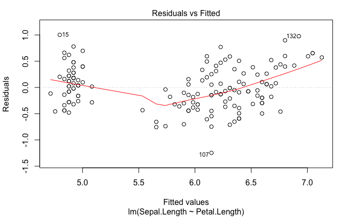

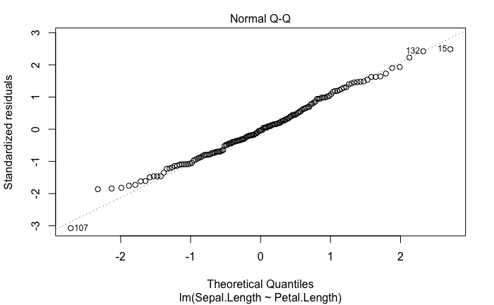

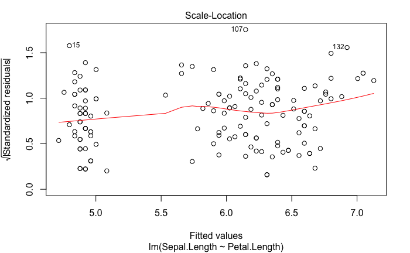

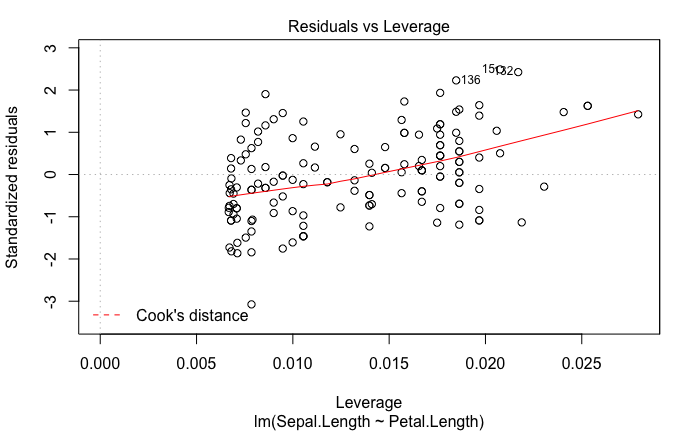

```r
plot(reg)
```

Les **méthodes** summary, print et plot sont implémentées pour tous les objets en R, et on peut les utiliser pour avoir un premier aperçu de ce que l’on obtient avec la fonction.

# Premier jeu de données, premières statistiques

## Importer les données et premier coup d’oeil

On peut importer n’importe quel format de données en R (excel, sas, stata, SQL…) et ceci est abordé dans le module 2. Pour ce module, nous ne voyons que l’importation de fichier .CSV. Si vous avez une base de données en excel ou libreOffice, sauvegardez l’onglet que vous souhaitez en faisant “enregistrer sous” $\rightarrow$ “délimité CSV”. Ici, nous travaillerons sur une base de données communales fournies par l’Insee, dite “comparateur de territoires”. Le fichier (excel) source figure sous le répertoire “data” et contient toutes les métadonnées ; nous avons ajouté une colonne correspondant au type ZAU de la commune concernée.

Utilisez la fonction read.csv pour importer ce fichier et stockez le dans un objet df. Veillez à ce que la région soit bien importée comme un facteur et non un entier. Inspectez ce nouvel objet.

```r
df <- read.csv(file = "../Data/Base_synth_territoires.csv",sep=";",dec=",")
str(df)
```

```
'data.frame':   36689 obs. of  38 variables:
 $ CODGEO       : Factor w/ 36689 levels "01001","01002",..: 1 2 3 4 5 6 7 8 9 10 ...
 $ LIBGEO       : Factor w/ 34174 levels "\xc8ve","\xc8vres",..: 13683 13685 813 815 832 855 859 954 1011 1173 ...
 $ REG          : int  84 84 84 84 84 84 84 84 84 84 ...
 $ DEP          : Factor w/ 100 levels "01","02","03",..: 1 1 1 1 1 1 1 1 1 1 ...
 $ ZAU          : Factor w/ 9 levels "111 - Grand p\xf4le (plus de 10 000 emplois)",..: 3 2 2 2 8 2 2 5 8 2 ...
 $ ZE           : Factor w/ 321 levels "0050 - Mont-de-Marsan",..: 260 248 248 260 263 248 248 263 266 250 ...
 $ P14_POP      : int  767 239 14022 1627 109 2570 743 338 1142 397 ...
 $ P09_POP      : int  787 207 13350 1592 120 2328 660 336 960 352 ...
 $ SUPERF       : num  15.95 9.15 24.6 15.92 5.88 ...
 $ NAIS0914     : int  40 16 1051 117 8 175 59 12 56 25 ...
 $ DECE0914     : int  25 7 551 41 3 78 20 11 32 10 ...
 $ P14_MEN      : num  306 99.3 6161.1 621.1 52.5 ...
 $ NAISD15      : int  13 5 222 15 2 21 11 2 18 4 ...
 $ DECESD15     : int  5 1 121 7 2 9 3 3 5 0 ...
```

[output cut: 24 more lines]

```r
df <- read.csv(file = "../Data/Base_synth_territoires.csv",sep=";",dec=",",colClasses = c("REG"="factor"))
str(df)
```

```
'data.frame':   36689 obs. of  38 variables:
 $ CODGEO       : Factor w/ 36689 levels "01001","01002",..: 1 2 3 4 5 6 7 8 9 10 ...
 $ LIBGEO       : Factor w/ 34174 levels "\xc8ve","\xc8vres",..: 13683 13685 813 815 832 855 859 954 1011 1173 ...
 $ REG          : Factor w/ 17 levels "01","02","03",..: 15 15 15 15 15 15 15 15 15 15 ...
 $ DEP          : Factor w/ 100 levels "01","02","03",..: 1 1 1 1 1 1 1 1 1 1 ...
 $ ZAU          : Factor w/ 9 levels "111 - Grand p\xf4le (plus de 10 000 emplois)",..: 3 2 2 2 8 2 2 5 8 2 ...
 $ ZE           : Factor w/ 321 levels "0050 - Mont-de-Marsan",..: 260 248 248 260 263 248 248 263 266 250 ...
 $ P14_POP      : int  767 239 14022 1627 109 2570 743 338 1142 397 ...
 $ P09_POP      : int  787 207 13350 1592 120 2328 660 336 960 352 ...
 $ SUPERF       : num  15.95 9.15 24.6 15.92 5.88 ...
 $ NAIS0914     : int  40 16 1051 117 8 175 59 12 56 25 ...
 $ DECE0914     : int  25 7 551 41 3 78 20 11 32 10 ...
 $ P14_MEN      : num  306 99.3 6161.1 621.1 52.5 ...
 $ NAISD15      : int  13 5 222 15 2 21 11 2 18 4 ...
 $ DECESD15     : int  5 1 121 7 2 9 3 3 5 0 ...
```

[output cut: 24 more lines]

Inspectez le dataframe avec les fonctions vues en cours… et plus !

```r
dim(df)
```

```
[1] 36689    38
```

```r
head(df)
```

|  | CODGEO | LIBGEO | REG | DEP | ZAU | ZE | P14_POP | P09_POP | SUPERF | NAIS0914 | DECE0914 | P14_MEN | NAISD15 | DECESD15 | P14_LOG | P14_RP | P14_RSECOCC | P14_LOGVAC | P14_RP_PROP | NBMENFISC13 | PIMP13 | MED13 | TP6013 | P14_EMPLT | P14_EMPLT_SAL | P09_EMPLT | P14_POP1564 | P14_CHOM1564 | P14_ACT1564 | … |
| --- | --- | --- | --- | --- | --- | --- | --- | --- | --- | --- | --- | --- | --- | --- | --- | --- | --- | --- | --- | --- | --- | --- | --- | --- | --- | --- | --- | --- | --- | --- |
| 1 | 01001 | L'Abergement-Cl\xe9menciat | 84 | 01 | 120 - Multipolaris\xe9e des grandes aires urbaines | 8213 - Villefranche-sur-Sa\xf4ne | 767 | 787 | 15.95 | 40 | 25 | 306.00000 | 13 | 5 | 342.73473 | 306.00000 | 13.99418 | 22.740550 | 260.00000 | 297 | NA | 22130.00 | NA | 85.157286 | 52.191539 | 65.566193 | 463.00000 | 33.000000 | 376.00000 | … |
| 2 | 01002 | L'Abergement-de-Varey | 84 | 01 | 112 - Couronne d'un grand p\xf4le | 8201 - Amb\xe9rieu-en-Bugey | 239 | 207 | 9.15 | 16 | 7 | 99.33745 | 5 | 1 | 161.16023 | 99.33745 | 47.27625 | 14.546538 | 84.58436 | 99 | NA | 23213.00 | NA | 12.814642 | 4.946329 | 17.644456 | 141.62963 | 9.835391 | 120.97531 | … |
| 3 | 01004 | Amb\xe9rieu-en-Bugey | 84 | 01 | 112 - Couronne d'un grand p\xf4le | 8201 - Amb\xe9rieu-en-Bugey | 14022 | 13350 | 24.60 | 1051 | 551 | 6161.06200 | 222 | 121 | 6838.35437 | 6161.06200 | 121.64795 | 555.644416 | 2769.00170 | 6034 | 57.41294 | 19554.00 | 15.11508 | 7452.926728 | 6743.374287 | 7551.682296 | 8962.84216 | 1059.728437 | 6681.86216 | … |
| 4 | 01005 | Amb\xe9rieux-en-Dombes | 84 | 01 | 112 - Couronne d'un grand p\xf4le | 8213 - Villefranche-sur-Sa\xf4ne | 1627 | 1592 | 15.92 | 117 | 41 | 621.05374 | 15 | 7 | 661.76017 | 621.05374 | 10.85505 | 29.851387 | 473.32736 | 617 | NA | 22387.62 | NA | 280.569953 | 206.382233 | 286.611037 | 1043.12909 | 66.326127 | 842.14083 | … |
| 5 | 01006 | Ambl\xe9on | 84 | 01 | 300 - Autre commune multipolaris\xe9e | 8216 - Chamb\xe9ry | 109 | 120 | 5.88 | 8 | 3 | 52.51818 | 2 | 2 | 71.51818 | 52.51818 | 10.85714 | 8.142857 | 37.65455 | 47 | NA | 21871.67 | NA | 5.945455 | 3.963636 | 5.285714 | 71.34545 | 7.927273 | 57.47273 | … |
| 6 | 01007 | Ambronay | 84 | 01 | 112 - Couronne d'un grand p\xf4le | 8201 - Amb\xe9rieu-en-Bugey | 2570 | 2328 | 33.55 | 175 | 78 | 1028.00000 | 21 | 9 | 1160.00000 | 1028.00000 | 56.00000 | 76.000000 | 779.00000 | 1014 | 62.35178 | 21650.67 | NA | 487.730918 | 372.758450 | 491.138876 | 1614.00000 | 108.000000 | 1267.00000 | … |

```r
tail(df)
```

|  | CODGEO | LIBGEO | REG | DEP | ZAU | ZE | P14_POP | P09_POP | SUPERF | NAIS0914 | DECE0914 | P14_MEN | NAISD15 | DECESD15 | P14_LOG | P14_RP | P14_RSECOCC | P14_LOGVAC | P14_RP_PROP | NBMENFISC13 | PIMP13 | MED13 | TP6013 | P14_EMPLT | P14_EMPLT_SAL | P09_EMPLT | P14_POP1564 | P14_CHOM1564 | P14_ACT1564 | … |
| --- | --- | --- | --- | --- | --- | --- | --- | --- | --- | --- | --- | --- | --- | --- | --- | --- | --- | --- | --- | --- | --- | --- | --- | --- | --- | --- | --- | --- | --- | --- |
| 36684 | 97419 | Sainte-Rose | 04 | 974 | 400 - Commune isol\xe9e hors influence des p\xf4les | 0401 - L'Est | 6722 | 6822 | 177.60 | 519 | 186 | 2322.000 | 94 | 43 | 2542.478 | 2322.000 | 28.58054 | 191.8979 | 1799.954 | NA | NA | NA | NA | 1272.841 | 920.0617 | 1269.573 | 4306.217 | 1250.516 | 2850.155 | … |
| 36685 | 97420 | Sainte-Suzanne | 04 | 974 | 112 - Couronne d'un grand p\xf4le | 0402 - Le Nord | 22406 | 22437 | 57.84 | 1963 | 508 | 7686.912 | 358 | 100 | 8328.616 | 7686.912 | 50.94097 | 590.7629 | 4450.648 | NA | NA | NA | NA | 4296.362 | 3618.1538 | 4185.015 | 14821.042 | 3712.486 | 10456.196 | … |
| 36686 | 97421 | Salazie | 04 | 974 | 400 - Commune isol\xe9e hors influence des p\xf4les | 0401 - L'Est | 7132 | 7406 | 103.82 | 661 | 235 | 2420.000 | 111 | 46 | 2987.000 | 2420.000 | 174.00000 | 393.0000 | 1849.000 | NA | NA | NA | NA | 1519.306 | 1090.0856 | 1533.305 | 4650.000 | 1369.000 | 3108.000 | … |
| 36687 | 97422 | Le Tampon | 04 | 974 | 111 - Grand p\xf4le (plus de 10 000 emplois) | 0404 - Le Sud | 76796 | 72658 | 165.43 | 6663 | 2004 | 29662.460 | 1339 | 420 | 32710.091 | 29662.460 | 1004.31703 | 2043.3140 | 15372.921 | NA | NA | NA | NA | 16145.620 | 12486.5465 | 14807.249 | 50316.640 | 12783.137 | 34446.789 | … |
| 36688 | 97423 | Les Trois-Bassins | 04 | 974 | 112 - Couronne d'un grand p\xf4le | 0403 - L'Ouest | 7198 | 7057 | 42.58 | 531 | 217 | 2484.887 | 104 | 54 | 2890.404 | 2484.887 | 67.58626 | 337.9313 | 1773.765 | NA | NA | NA | NA | 1273.858 | 994.3469 | 1202.079 | 4850.570 | 1360.617 | 3524.287 | … |
| 36689 | 97424 | Cilaos | 04 | 974 | 400 - Commune isol\xe9e hors influence des p\xf4les | 0404 - Le Sud | 5295 | 5989 | 84.40 | 430 | 186 | 2016.000 | 87 | 38 | 2732.690 | 2016.000 | 239.56501 | 477.1253 | 1522.480 | NA | NA | NA | NA | 1194.383 | 993.1546 | 1314.121 | 3461.457 | 1122.361 | 2415.666 | … |

```r
str(df)
```

```
'data.frame':   36689 obs. of  38 variables:
 $ CODGEO       : Factor w/ 36689 levels "01001","01002",..: 1 2 3 4 5 6 7 8 9 10 ...
 $ LIBGEO       : Factor w/ 34174 levels "\xc8ve","\xc8vres",..: 13683 13685 813 815 832 855 859 954 1011 1173 ...
 $ REG          : Factor w/ 17 levels "01","02","03",..: 15 15 15 15 15 15 15 15 15 15 ...
 $ DEP          : Factor w/ 100 levels "01","02","03",..: 1 1 1 1 1 1 1 1 1 1 ...
 $ ZAU          : Factor w/ 9 levels "111 - Grand p\xf4le (plus de 10 000 emplois)",..: 3 2 2 2 8 2 2 5 8 2 ...
 $ ZE           : Factor w/ 321 levels "0050 - Mont-de-Marsan",..: 260 248 248 260 263 248 248 263 266 250 ...
 $ P14_POP      : int  767 239 14022 1627 109 2570 743 338 1142 397 ...
 $ P09_POP      : int  787 207 13350 1592 120 2328 660 336 960 352 ...
 $ SUPERF       : num  15.95 9.15 24.6 15.92 5.88 ...
 $ NAIS0914     : int  40 16 1051 117 8 175 59 12 56 25 ...
 $ DECE0914     : int  25 7 551 41 3 78 20 11 32 10 ...
 $ P14_MEN      : num  306 99.3 6161.1 621.1 52.5 ...
 $ NAISD15      : int  13 5 222 15 2 21 11 2 18 4 ...
 $ DECESD15     : int  5 1 121 7 2 9 3 3 5 0 ...
```

[output cut: 24 more lines]

```r
names(df)
```

```
 [1] "CODGEO"        "LIBGEO"        "REG"           "DEP"           "ZAU"           "ZE"
 [7] "P14_POP"       "P09_POP"       "SUPERF"        "NAIS0914"      "DECE0914"      "P14_MEN"
[13] "NAISD15"       "DECESD15"      "P14_LOG"       "P14_RP"        "P14_RSECOCC"   "P14_LOGVAC"
[19] "P14_RP_PROP"   "NBMENFISC13"   "PIMP13"        "MED13"         "TP6013"        "P14_EMPLT"
[25] "P14_EMPLT_SAL" "P09_EMPLT"     "P14_POP1564"   "P14_CHOM1564"  "P14_ACT1564"   "ETTOT14"
[31] "ETAZ14"        "ETBE14"        "ETFZ14"        "ETGU14"        "ETGZ14"        "ETOQ14"
[37] "ETTEF114"      "ETTEFP1014"
```

```r
class(df)
```

```
[1] "data.frame"
```

```r
typeof(df)
```

```
[1] "list"
```

```r
# Accéder a une variable directement (on obtient un vecteur) :
df$CODGEO[1:10] # Captain crochet poweeeeerr !!!
```

```
 [1] 01001 01002 01004 01005 01006 01007 01008 01009 01010 01011
36689 Levels: 01001 01002 01004 01005 01006 01007 01008 01009 01010 01011 01012 01013 01014 ... 97424
```

```r
class(df$CODGEO)
```

```
[1] "factor"
```

```r
typeof(df$CODGEO)
```

```
[1] "integer"
```

```r
length(df)
```

```
[1] 38
```

```r
length(df$region)
```

```
[1] 0
```

## Créer, filtrer, sélectionner

```r
df <- mutate(df,densite=P14_POP/SUPERF,tx_natal=1000*NAISD15/P14_POP,tx_mort=DECESD15/P14_POP)
```

A l’aide de la fonction `select()`, créez une nouvelle table dans laquelle vous ne gardez que le code commune, le type de commune (ZAU), la région, le département et les variables que vous venez de créer.

```r
selection <- select(df,CODGEO,ZAU,REG,DEP,densite,tx_natal,tx_mort)
```

Enfin, ne retenez les communes correspondant à votre département de naissance et stocker. Faites attention au type de la variable département !

```r
S0 <- filter(selection,DEP=="62")
```

On va maintenant jouer avec les opérateurs logiques pour sélectionner des échantillons différents !

```r
S1 <- filter(selection,DEP!="62") # tout sauf le 62 :(
S2 <- filter(selection,DEP %in% c("59","62")) # L'ancien NPdC :)
S3 <- filter(selection,!(DEP %in% c("59","62"))) # Le "sud" de la France
S4 <- filter(selection,densite>100) # l'urbain
S5 <- filter(selection,DEP=="62" & densite>100) # le PdC urbain
S6 <- filter(selection, DEP=="62" | densite > 100) # le PdC et l'urbain
```

**Nom d’un pipe `%>%` !**

On peut combiner les opérations en une seule ligne à l’aide du pipe `%>%` :

```r
selection <- select(df,CODGEO,ZAU,REG,DEP,densite,tx_natal,tx_mort) %>%
             filter(DEP=="62")
```

**Le coin du capitaine [ ]**

[figure not shown]

Pour sélectionner les données, on peut également utiliser les crochets couplés aux dollars et aux `c()`, sans passer par les numéros de lignes et colonnes ! On rencontre assez souvent cette syntaxe sur les forums.

```r
selection <- df[df$DEP=="62",c("CODGEO","ZAU","REG","DEP","densite","tx_natal","tx_mort")]
```

*Note* : dans la syntaxe `tidyverse`, on ne met pas (obligatoirement) de guillemets pour les noms de variable, alors qu’on le fait pour la version [ ]

# Mes premiers graphiques et statistiques

## Statistiques univariées

Utilisdez la fonction `summary` pour obtenir un résumé de l’ensemble des variables de la table df

```r
df <- mutate(df,ZAU2=as.factor(substr(ZAU,1,3)))
### Parce que la variable originale est trop longue et caractères bizarres
summary(df)
```

```
     CODGEO                 LIBGEO           REG             DEP
 01001  :    1   Sainte-Colombe:   13   44     : 5198   62     :  895
 01002  :    1   Beaulieu      :   11   76     : 4565   02     :  816
 01004  :    1   Saint-Sauveur :   11   75     : 4505   80     :  782
 01005  :    1   Sainte-Marie  :   11   84     : 4189   76     :  745
 01006  :    1   Le Pin        :   10   32     : 3838   57     :  730
 01007  :    1   Saint-Aubin   :   10   27     : 3831   14     :  707
 (Other):36683   (Other)       :36623   (Other):10563   (Other):32014
   ZAU                                                                             ZE
 112 - Couronne d'un grand p\xf4le                  :12297   0061 - Toulouse        :  717
 400 - Commune isol\xe9e hors influence des p\xf4les: 7383   2307 - Rouen           :  501
 300 - Autre commune multipolaris\xe9e              : 7021   2210 - Amiens          :  479
 120 - Multipolaris\xe9e des grandes aires urbaines : 3962   7310 - Tarbes - Lourdes:  455
 111 - Grand p\xf4le (plus de 10 000 emplois)       : 3285   2102 - Troyes          :  452
 221 - Petit p\xf4le (de 1 500 \xe0 5 000 emplois)  :  888   2603 - Dijon           :  448
 (Other)                                            : 1853   (Other)                :33637
    P14_POP           P09_POP            SUPERF            NAIS0914           DECE0914
 Min.   :      0   Min.   :      0   Min.   :    0.04   Min.   :     0.0   Min.   :    0.00
 1st Qu.:    197   1st Qu.:    193   1st Qu.:    6.44   1st Qu.:     9.0   1st Qu.:    8.00
 Median :    444   Median :    431   Median :   10.81   Median :    23.0   Median :   17.00
 Mean   :   1838   Mean   :   1793   Mean   :   17.64   Mean   :   114.4   Mean   :   77.35
 3rd Qu.:   1110   3rd Qu.:   1072   3rd Qu.:   18.58   3rd Qu.:    60.0   3rd Qu.:   43.00
 Max.   :2220445   Max.   :2234105   Max.   :18360.00   Max.   :150843.0   Max.   :69907.00
 NA's   :821       NA's   :821       NA's   :821        NA's   :821        NA's   :821
    P14_MEN             NAISD15            DECESD15           P14_LOG              P14_RP
 Min.   :      0.0   Min.   :    0.00   Min.   :    0.00   Min.   :      0.0   Min.   :      0.0
 1st Qu.:     83.8   1st Qu.:    1.00   1st Qu.:    1.00   1st Qu.:    115.0   1st Qu.:     83.8
 Median :    183.2   Median :    4.00   Median :    3.00   Median :    239.1   Median :    183.2
 Mean   :    802.0   Mean   :   21.96   Mean   :   16.47   Mean   :    970.2   Mean   :    802.0
 3rd Qu.:    454.9   3rd Qu.:   11.00   3rd Qu.:    9.00   3rd Qu.:    565.0   3rd Qu.:    454.9
 Max.   :1147990.9   Max.   :28267.00   Max.   :13997.00   Max.   :1362181.9   Max.   :1147990.9
 NA's   :821         NA's   :821        NA's   :821        NA's   :821         NA's   :821
  P14_RSECOCC          P14_LOGVAC         P14_RP_PROP        NBMENFISC13            PIMP13
 Min.   :     0.00   Min.   :     0.00   Min.   :     0.0   Min.   :     32.0   Min.   :24.46
 1st Qu.:     7.00   1st Qu.:     8.00   1st Qu.:    68.4   1st Qu.:    102.0   1st Qu.:50.57
 Median :    19.00   Median :    18.00   Median :   148.0   Median :    205.0   Median :58.40
 Mean   :    91.63   Mean   :    76.60   Mean   :   462.2   Mean   :    809.7   Mean   :58.98
 3rd Qu.:    49.29   3rd Qu.:    43.75   3rd Qu.:   349.2   3rd Qu.:    484.0   3rd Qu.:67.19
 Max.   :107061.99   Max.   :107129.02   Max.   :381934.3   Max.   :1038789.0   Max.   :89.38
 NA's   :821         NA's   :821         NA's   :821        NA's   :3793        NA's   :31598
```

[output cut: 25 more lines]

```
 Min.   :     0.00   Min.   :    0.00   Min.   :    0.00   Min.   :  0.000   Min.   :0.0000
 1st Qu.:     4.00   1st Qu.:    0.00   1st Qu.:   18.59   1st Qu.:  5.679   1st Qu.:0.0044
 Median :     8.00   Median :    1.00   Median :   40.35   Median :  9.264   Median :0.0079
 Mean   :    41.33   Mean   :   10.28   Mean   :  160.15   Mean   :  9.699   Mean   :0.0093
 3rd Qu.:    19.00   3rd Qu.:    4.00   3rd Qu.:   94.57   3rd Qu.: 12.931   3rd Qu.:0.0124
 Max.   :124131.00   Max.   :24527.00   Max.   :27126.14   Max.   :111.111   Max.   :0.1577
 NA's   :25          NA's   :25         NA's   :821        NA's   :827       NA's   :827
      ZAU2
 112    :12297
 400    : 7383
 300    : 7021
 120    : 3962
 111    : 3285
 221    :  888
 (Other): 1853
```

Calculez maintenant les moyenne, médiane, écart-type et variance de la variable de densité de population

```r
mean(df$densite)
```

```
[1] NA
```

```r
sd(df$densite)
```

```
[1] NA
```

```r
median(df$densite)
```

```
[1] NA
```

```r
var(df$densite)
```

```
[1] NA
```

Il y a des valeurs manquantes, qui sont absorbantes ! On ajoute un paramètre pour calculer uniquement sur les valeurs renseignées

```r
mean(df$densite,na.rm = T)
```

```
[1] 160.151
```

```r
sd(df$densite,na.rm = T)
```

```
[1] 722.799
```

```r
median(df$densite,na.rm = T)
```

```
[1] 40.35457
```

```r
var(df$densite,na.rm = T)
```

```
[1] 522438.4
```

**Application** : calculez la version centrée réduite de la variable de densité. Rappel : on calcule la version centrée réduite d’une variable X en lui appliquant la transformation suivante :
$$STD_X = \dfrac{X-\bar{X}}{\sigma_X}$$
où $\bar{X}$ est la moyenne empirique de X et $\sigma_X$ son écart-type Avantage : on élimine les effets d’unité (d’ordre de grandeur)

```r
df <- mutate(df,std_dens=(densite-mean(densite,na.rm = T))/sd(densite,na.rm = T))
mean(df$std_dens,na.rm = T)
```

```
[1] 9.482279e-18
```

```r
sd(df$std_dens, na.rm = T)
```

```
[1] 1
```

Calulez à présent les quartiles puis déciles de cette variables

```r
quantile(df$densite,na.rm = T)
```

```
         0%         25%         50%         75%        100%
    0.00000    18.59047    40.35457    94.57430 27126.14108
```

```r
quantile(df$densite,probs = seq(0,1,.1),na.rm = T)
```

```
         0%         10%         20%         30%         40%         50%         60%         70%
    0.00000    10.03439    15.65357    21.84208    29.76144    40.35457    54.82089    77.65199
        80%         90%        100%
  119.08740   240.40789 27126.14108
```

## Tableaux croisés

- Une variable

Calculez le nombre de communes par type d’espace à l’aide de la fonction table, et le pourcentage associé

```r
t <- table(df$ZAU2)
t
```

```
  111   112   120   211   212   221   222   300   400
 3285 12297  3962   456   815   888   582  7021  7383
```

```r
100*prop.table(t) %>% round(digits = 4)
```

```
  111   112   120   211   212   221   222   300   400
 8.95 33.52 10.80  1.24  2.22  2.42  1.59 19.14 20.12
```

- Deux variables

```r
t <- table(df$REG,df$ZAU2)
t
```

```
      111  112  120  211  212  221  222  300  400
  01   17    6    1    0    0    3    0    2    3
  02   16    0    4    3    0    2    0    4    5
  03    3    3    0    2    0    1    0    0   13
  04   10    3    4    2    0    0    0    1    4
  11  413  853    3    3    2    0    0    7    0
  24  103  734  188   30   72   46   19  375  275
  27  140 1299  336   31  122   60  137  737  969
  28  216 1126  488   34  104   78   29  762  396
  32  481 1505  729   33   18   54   18  711  289
  44  322 1721  822   54  102   89  118 1155  815
  52  108  535  186   23   44   69    8  386  143
  53   89  415  152   47   18   42    1  325  181
  75  333 1161  254   51   81  163   81 1002 1379
  76  258 1124  333   79  155  123   89  877 1527
  84  548 1484  390   43   84  113   47  517  963
  93  220  229   69   20   11   32    6  107  269
  94    8   99    3    1    2   13   29   53  152
```

```r
100*prop.table(t) %>% round(digits = 4)
```

```
      111  112  120  211  212  221  222  300  400
  01 0.05 0.02 0.00 0.00 0.00 0.01 0.00 0.01 0.01
  02 0.04 0.00 0.01 0.01 0.00 0.01 0.00 0.01 0.01
  03 0.01 0.01 0.00 0.01 0.00 0.00 0.00 0.00 0.04
  04 0.03 0.01 0.01 0.01 0.00 0.00 0.00 0.00 0.01
  11 1.13 2.32 0.01 0.01 0.01 0.00 0.00 0.02 0.00
  24 0.28 2.00 0.51 0.08 0.20 0.13 0.05 1.02 0.75
  27 0.38 3.54 0.92 0.08 0.33 0.16 0.37 2.01 2.64
  28 0.59 3.07 1.33 0.09 0.28 0.21 0.08 2.08 1.08
  32 1.31 4.10 1.99 0.09 0.05 0.15 0.05 1.94 0.79
  44 0.88 4.69 2.24 0.15 0.28 0.24 0.32 3.15 2.22
  52 0.29 1.46 0.51 0.06 0.12 0.19 0.02 1.05 0.39
  53 0.24 1.13 0.41 0.13 0.05 0.11 0.00 0.89 0.49
  75 0.91 3.16 0.69 0.14 0.22 0.44 0.22 2.73 3.76
  76 0.70 3.06 0.91 0.22 0.42 0.34 0.24 2.39 4.16
  84 1.49 4.04 1.06 0.12 0.23 0.31 0.13 1.41 2.62
  93 0.60 0.62 0.19 0.05 0.03 0.09 0.02 0.29 0.73
  94 0.02 0.27 0.01 0.00 0.01 0.04 0.08 0.14 0.41
```

Pour aller plus loin et ajouter des variables de pondération, calculer les profils-ligne ou profils-colonne, rendez-vous au module 3, ou demandez à votre GF (Gentil Formateur)

## Les graphiques avec ggplot2

On reprend la base non filtrée. A l’aide de la cheat sheet ggplot2, réalisez un histogramme de la densite de population.

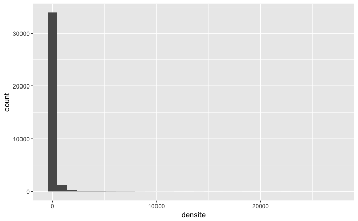

```r
ggplot(data = df,aes(x=densite)) + geom_histogram()
```

C’est pas très informatif, mais on peut faire une transformation log pour y voir plus clair !

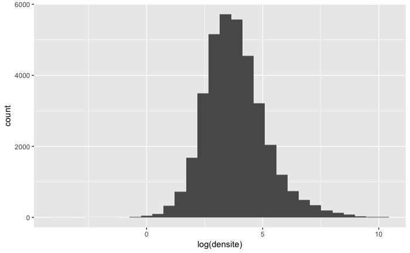

```r
ggplot(data = df,aes(x=log(densite))) + geom_histogram()
```

Faites maintenant un barplot (qui n’est pas un histogramme !!!! ) du nombre de communes par type ZAU

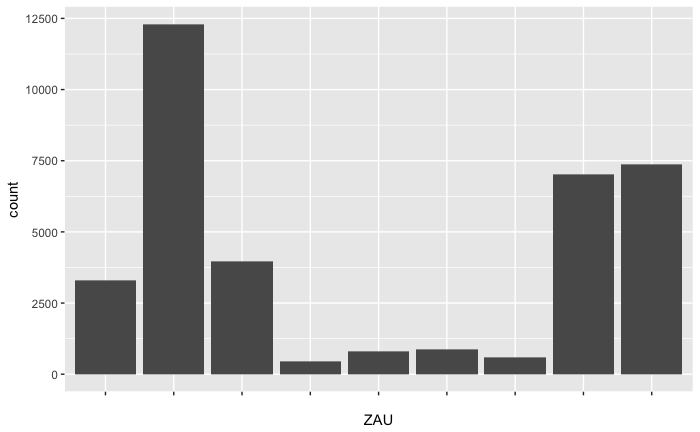

```r
ggplot(data=df,aes(x=ZAU)) + geom_bar()
```

On va essayer d’y voir plus clair avec le paramètre `fill`

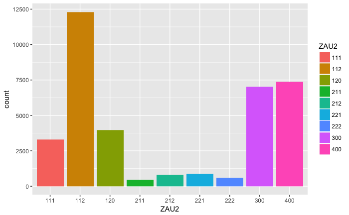

```r
ggplot(data=df,aes(x=ZAU2,fill=ZAU2)) + geom_bar()
```

Réalisez un graphique (unage de points) croisant la densité de population et le taux de mortalité

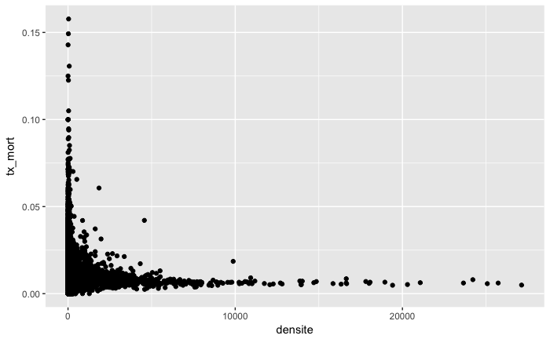

```r
ggplot(data=df,aes(x=densite,y=tx_mort)) + geom_point()
```

On peut ajouter une dimension supplémentaire avec la couleur des points

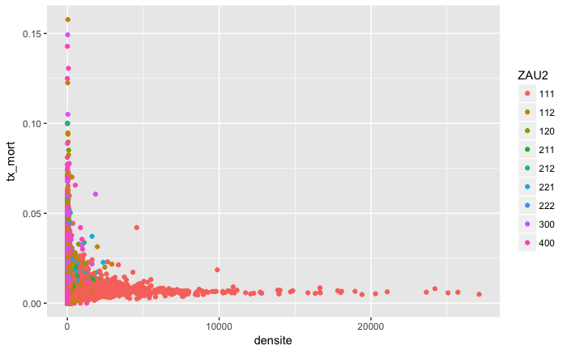

```r
ggplot(data=df,aes(x=densite,y=tx_mort,color=ZAU2)) + geom_point()
```

Là encore il faudrait faire une transformation logarithmique, mais tout ça est abordé dans le module 3 !

Avec les fonctions de base, on peut obtenir de nombreux graphiques avec très peu de code, mais moins jolis :

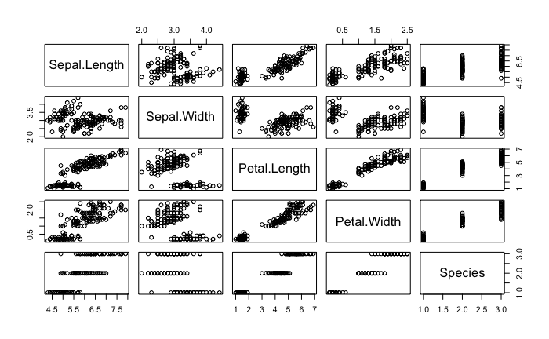

```r
plot(iris)
```

Des possibilités infinies à approfondir dans les modules 3 et 5 !!!!!